# 2.1 Bootstrap paramétrico

** Escribe la función de log-verosimilitud y calcula el estimador de máxima verosimilitud para $\sigma^2$. Supongamos que observamos los datos `x` (en la carpeta datos), ¿Cuál es tu estimación de la varianza?**

Al calcular analíticamente la función de log verosimilitud se considera la likelihood y prior de las funciones. De esta forma:

La normal sigue la siguiente distribución:
$$f(x) = \frac{1}{\sqrt{2\pi \sigma^2}} \exp\Bigg(\frac{1}{2\sigma^2}(x -\mu)^2\Bigg)$$

De manera que, dada una muestra $x_1, x_2, x_3, ..., x_n$, se puede escribir la Likelihood de la siguiente forma:

$$L(x) = \frac{1}{ ( 2\pi \sigma^2)^{n/2}} \exp(\frac{1}{2\sigma^2}\sum_i(x_i -\mu)^2)$$

Por lo tanto, usando $a = \sigma^2$ es intuitivo expresar la log-likelihood como:
$$l(x) = -\frac{n}{2} log(2\pi) - \frac{n}{2}log(\sigma^2) - \frac{1}{2\sigma^2}\sum_i (x_i-\mu)^2 \\
l(x) = -\frac{n}{2} log(2\pi) - \frac{n}{2}log(a) - \frac{1}{2a}\sum_i (x_i-\mu)^2$$
Al derivarparcialmente con respecto a $\sigma^2$ e igualando a 0, obtenemos la siguiente expresión:
$$\frac{\partial l(x)}{\partial a} = -\frac{n}{2a} - \Bigg[ \frac{1}{2}\sum_i (x_i-\mu)^2 \Bigg]\Bigg[ -\frac{1}{a^2} \Bigg] \\
-\frac{n}{2a} + \Bigg[ \frac{1}{2a^2}\sum_i (x_i-\mu)^2 \Bigg] \\
\frac{1}{2a} \Bigg[ \frac{1}{a} \sum_i (x_i-\mu)^2 - n \Bigg] = 0 \\
a = \frac{\sum_i (x_i-\mu)^2}{n}$$

De esta forma, el estimador MLE de $\sigma$ lo podemos expresar como:

$$\hat{\sigma}^2 = \frac{\sum_i (x_i-\mu)^2}{n}$$

Para encontrarla con la función optim como vimos en clase, en lugar de analíticamente, hacemos uso de la funcion crear_log_p. Esta funcion nos ayuda a generar las funciones log_p.

```r
library(tidyverse)
# La función crear_log_p crea una funcion llamada log_p que recibe dos parámetros (media, sigma) tal que se estandariza la funcion y se calcula su respectiva log verosimilitud
crear_log_p <- function(x){
  log_p <- function(pars){
    media = pars[1]
    desv_est = pars[2]
    z <- (x - media) / desv_est
    log_verosim <- -(log(desv_est) +  0.5 * mean(z^2))
    log_verosim
  }
  log_p
}
```

Con esto procedemos a cargar los datos y optimizarlo con la función optim:

```r
load("data/x.RData")
muestra <- x

var_sesgada <- sum((x-mean(x))^2)/length(x)
var_insesgada <- sum((x-mean(x))^2)/(length(x)-1)
var(x)
```

```
## [1] 131.8516
```

```r
log_p <- crear_log_p(muestra)

res <-
  optim(
    par = c(0, 0.5),
    fn = log_p,
    control = list(fnscale = -1, maxit = 10000),
    method = "Nelder-Mead"
    )

est_mle <-
  tibble(
    parametro = c("media", "sigma"),
    estimador = res$par
    ) %>%
  column_to_rownames(var = "parametro")
```

Al comparar el estimador que calculamos analíticamente con el proporcionado con la función optim, vemos que solamente hay una diferencia de:

```r
sqrt(var_sesgada)-res$par[2]
```

```
## [1] 0.007658511
```

Cuando se usa función *var* de R, nos toma la segunda forma que es la versión insesgada. Pero en este ejemplo, nosotros estaremos ocupando la primera debido a que es el que tenemos como resultado del MLE.

** Aproxima el error estándar de la estimación usando **bootstrap paramétrico** y realiza un histograma de las replicaciones bootstrap.**

Para el aproximar el error estándar usando boostrap paramétrico hacemos uso de las funciones generadas en clase (con sus respectivas modificaciones)

```r
# simular_modelo encuentra n número de observaciones de una distribución normal con la media y sigma proporcionada
simular_modelo <- function(n, media, sigma){
  rnorm(n, media, sigma)
}
```

```r
# la función rep_boot repite
rep_boot <- function(rep, crear_log_p, est_mle, n){
  muestra_bootstrap <-
    simular_modelo(
      n = length(muestra),
      media = est_mle["media", "estimador"],
      sigma = est_mle["sigma", "estimador"]
      )

  log_p_boot <- crear_log_p(muestra_bootstrap)

  # optimizamos

  res_boot <-
    optim(
      par = c(0, 0.5),
      fn = log_p_boot,
      control = list(fnscale = -1, maxit = 1000),
      method = "Nelder-Mead"
      )

  try(if(res_boot$convergence != 0) stop("No se alcanzó convergencia."))
  tibble(parametro = c("media", "sigma"), estimador_boot = res_boot$par)
}
```

```r
reps_boot <- map_dfr(
  .x = 1:5000,
  .f = ~ rep_boot(.x, crear_log_p, est_mle, n = length(muestra)),
  rep = ".id"
  )

reps_boot %>% nrow()
```

```
## [1] 10000
```

```r
error_est <-
  reps_boot %>%
  group_by(parametro) %>%
  summarise(ee_boot = sd(estimador_boot))
bind_cols(est_mle, error_est) %>%
  mutate(across(where(is.numeric), round, 3)) %>%
  select(parametro, estimador, ee_boot)
```

```
##   parametro estimador ee_boot
## 1     media     0.560   0.949
## 2     sigma    11.437   0.665
```

Mostrando el histograma tanto de sigma como de la media:

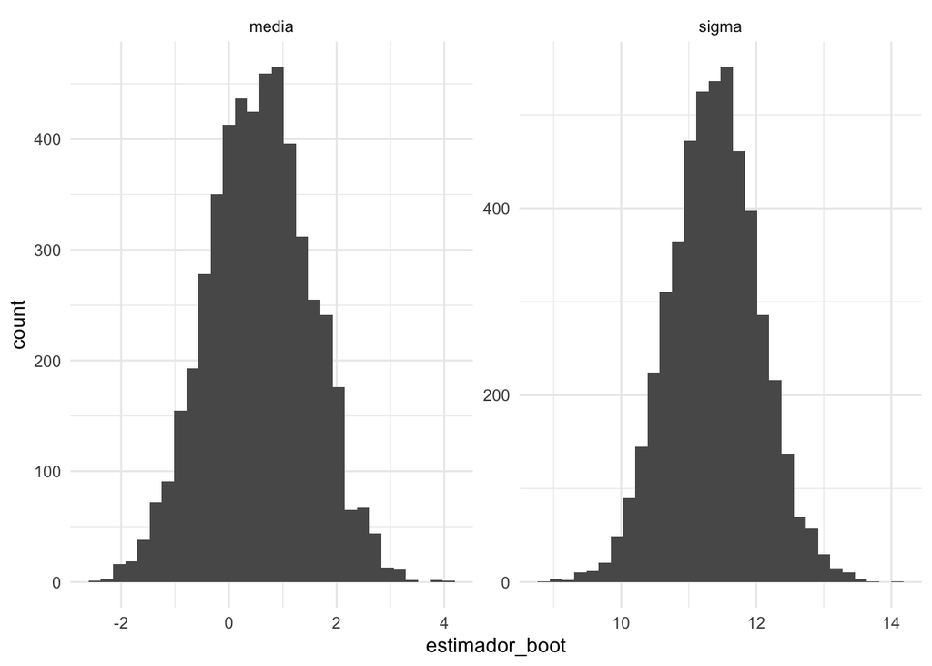

```r
reps_boot %>%
  ggplot(aes(x = estimador_boot)) +
  geom_histogram()+
  facet_wrap(~parametro, scales = "free")+
  theme_minimal()
```